# Polygenic risk scores of Brad Ruzicka’s chort

Yongjin Park

2020-04-09 13:59:05

### GWAS summary data

We obtained publicly avaiable GWAS summary statistics from the three different sources:

1. CTG: [Complex Trait Genetics Lab](https://ctg.cncr.nl/).
2. PGC: [Psychiatric Genomics Consortium](https://www.med.unc.edu/pgc/).
3. SSGAC: [Social Science Genetic Association Consortium](https://www.thessgac.org/).

Of all the traits, we investigate on the GWAS data collected from individuals of European ancestry, and summary statistics complete with both effect sizes and standard errors.

- AD (CTG): Alzheimer’s disease case/control (Jansen et al., 2018)
- DEPRESSED-A (CTG): depressed affect (of neuroticism) case/control (Nagel et al., 2018)
- WORRY (CTG): Worry (of neuroticism) case/control (Nagel et al., 2018)
- INSOMNIA (CTG): Insomnia case/control (Jansen et al., 2019)
- IQ (CTG): Intelligence meta-analysis across relevant phenotypes (Savage et al., 2018)
- ADHD (PGC): Attention-deficit/hyperactivity disorder case/control (Neale et al., 2010)
- ASD (PGC): Autism spectrum disorder case/control (Autism Spectrum Disorders Working Group of The Psychiatric Genomics Consortium, 2017)
- BIP (PGC): Bipolar disorder case/control (Stahl et al., 2018)
- MDD (PGC): Major depressive disorder case/control (Wray et al., 2018)
- OCD (PGC): Obsessive-compulsive disorder case/control (International Obsessive Compulsive Disorder Foundation Genetics Collaborative (IOCDF-GC) and OCD Collaborative Genetics Association Studies (OCGAS), 2018)
- PTSD (PGC): Post-traumatic stress disorder case/control (Duncan et al., 2018)
- SCZ (PGC): Schizophrenia case/control (Schizophrenia Working Group of the Psychiatric Genomics Consortium, 2014)
- COG (SSGAC): cognitive performance (Lee et al., 2018)
- EDU (SSGAC): educational attainment (Lee et al., 2018)
- EVER-SMOKE (SSGAC): Ever smoker case/control meta-analysis of TAG consortium with UK Biobank (Karlsson Linnér et al., 2019)
- SPEEDING (SSGAC): Automobile speeding propensity in UK Biobank (Karlsson Linnér et al., 2019)
- NDRINK-WEEK (SSGAC): Number of drinks per week in UK Biobank (Karlsson Linnér et al., 2019)
- NSEX-PART (SSGAC): Number of sexual partners in UK Biobank (Karlsson Linnér et al., 2019)
- RISK-PC1 (SSGAC): The first principle components of the four risky behaviors (Karlsson Linnér et al., 2019)
- RISK-TOL (SSGAC): Risk tolerance (Karlsson Linnér et al., 2019)

## Results

### The results of Schizophrenia PRS

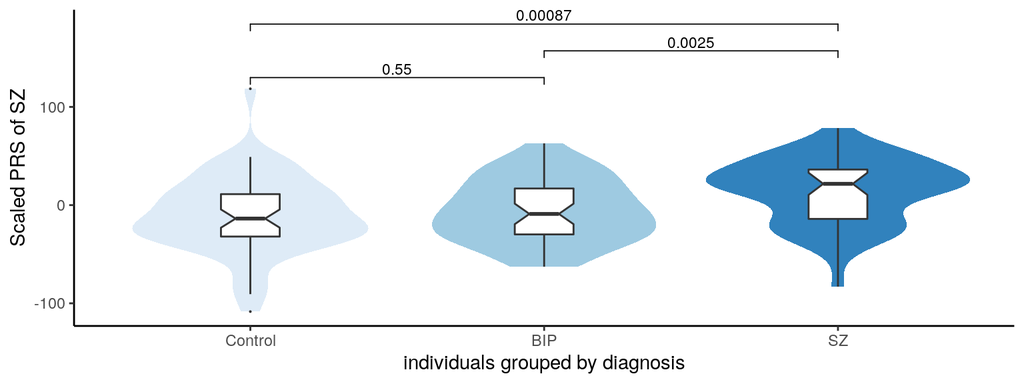

PDF

Since we have the actual phenotype information for these individuals, we can estimate the proportion of variance explained by PRS models by fitting a generalized linear model.

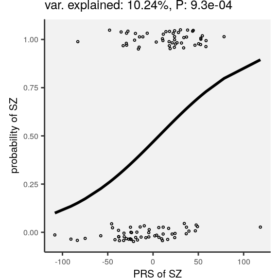

PDF

### The results of Bipolar disorder PRS

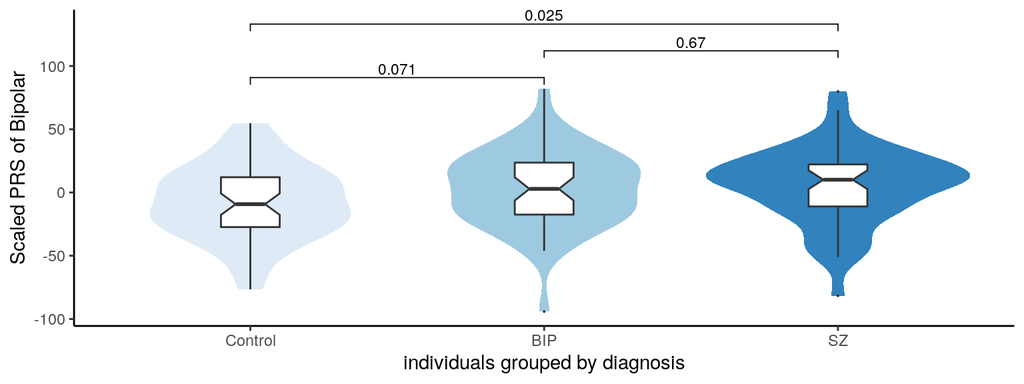

PDF

### Patient groups

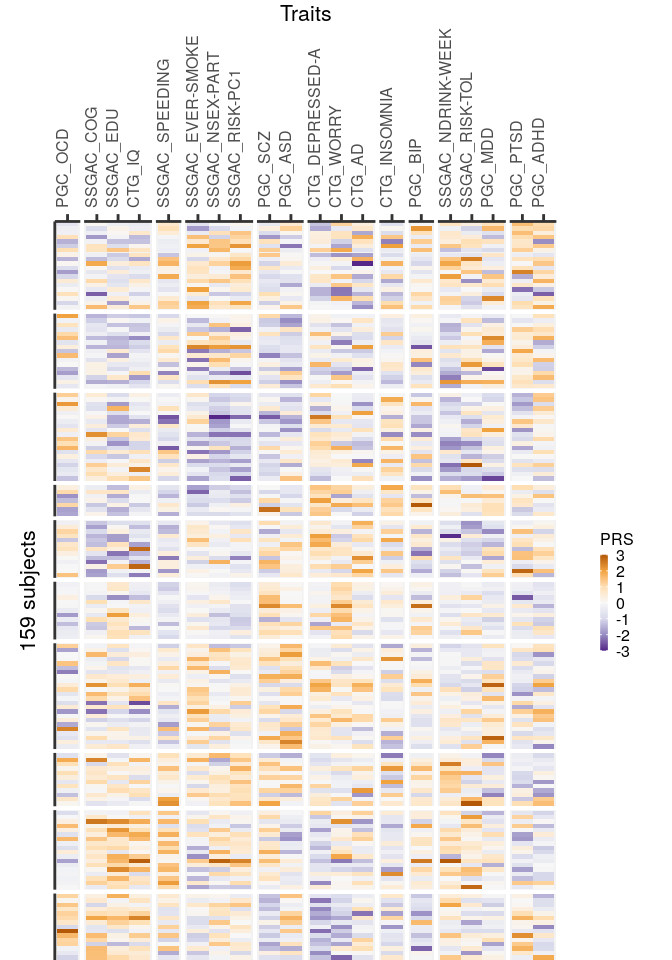

PDF

## methods

### Robust polygenic risk score prediction by spectral decomposition

We estimate polygenic risk score (PRS) using spectral decomposition of the underlying genotype matrix, $X$ (sample by variants), of the cohort. We propose a robust and straightforward PRS method that estimates a vector of multivariate effect size, $\boldsymbol{\theta}$, from a vector of univariate GWAS summary statistics. If we have sufficiently large number of individuals, we can simply estimate $\boldsymbol{\theta} = R^{-1} \mathbf{z}$ by taking an inverse matrix of the LD matrix, namely $R \overset{\Delta}{=} X^{\top}X/n$. In practice, we take the psuedo-inverse of $R$, namely $R^{-1}\approx VD^{-2}V^{\top}$, based on singular value decomposition of the genotype matrix, $X=UDV^{\top}$, and this results in the estimate of multivariate effect size $\boldsymbol{\theta} \approx VD^{-2}V^{\top}\mathbf{z}$. By substituting this result to a linear model, $\mathbf{y} \sim X \boldsymbol{\theta}$, we predict a PRS vector, $\hat{\mathbf{y}} = UD^{-1}V^{\top}\mathbf{z}$. To account for discrepancy of the LD matrix $R$ between our cohort and the actual GWAS cohort, we introduce regularization parameter $\tau$ (ridge regression): $\hat{\mathbf{y}} = U(D + \tau I)^{-1}V^{\top} \mathbf{z}$.

### Hyper-parameter tuning without phenotype labels

Here we use the genotypes of 159 individuals as a primary matrix $X$, while additionally using the 1000G reference panel genotype matrix $\tilde{X}$. Let us define the multivariate regression parameters $\hat{\theta}(\tau) \overset{\Delta}{=} V(D + \tau I)^{-2}V^{\top}\mathbf{z}$ as a function of the hyperparameter $\tau$. We can construct a prediction vector on a new genotype matrix $\tilde{X}$ for each $\tau$ value, namely $\mathbf{y}(\tau)\overset{\Delta}{=} \tilde{X} \hat{\theta}(\tau)$. On the other hand, based on the SVD of the 1000G panel, namely $\tilde{X} = \tilde{U} \tilde{D} \tilde{V}^{\top}$, we can construct another PRS vector $\tilde{\mathbf{y}} = \tilde{U} \tilde{D}^{-1} \tilde{V}^{\top} \mathbf{z}$.

## Reference

Autism Spectrum Disorders Working Group of The Psychiatric Genomics Consortium. (2017). Meta-analysis of GWAS of over 16,000 individuals with autism spectrum disorder highlights a novel locus at 10q24.32 and a significant overlap with schizophrenia. *Mol. Autism*, *8*, 21.

Duncan, L. E., Ratanatharathorn, A., Aiello, A. E., Almli, L. M., Amstadter, A. B., Ashley-Koch, A. E., … Koenen, K. C. (2018). Largest GWAS of PTSD (n=20 070) yields genetic overlap with schizophrenia and sex differences in heritability. *Mol. Psychiatry*, *23*(3), 666–673.

International Obsessive Compulsive Disorder Foundation Genetics Collaborative (IOCDF-GC) and OCD Collaborative Genetics Association Studies (OCGAS). (2018). Revealing the complex genetic architecture of obsessive-compulsive disorder using meta-analysis. *Mol. Psychiatry*, *23*(5), 1181–1188.

Jansen, I., Savage, J., Watanabe, K., Bryois, J., Williams, D., Steinberg, S., … Posthuma, D. (2018). *Genetic meta-analysis identifies 9 novel loci and functional pathways for alzheimers disease risk*. *bioRxiv*.

Jansen, P. R., Watanabe, K., Stringer, S., Skene, N., Bryois, J., Hammerschlag, A. R., … Posthuma, D. (2019). Genome-wide analysis of insomnia in 1,331,010 individuals identifies new risk loci and functional pathways. *Nat. Genet.*, *51*(3), 394–403.

Karlsson Linnér, R., Biroli, P., Kong, E., Meddens, S. F. W., Wedow, R., Fontana, M. A., … Beauchamp, J. P. (2019). Genome-wide association analyses of risk tolerance and risky behaviors in over 1 million individuals identify hundreds of loci and shared genetic influences. *Nat. Genet.*, *51*(2), 245–257.

Lee, J. J., Wedow, R., Okbay, A., Kong, E., Maghzian, O., Zacher, M., … Cesarini, D. (2018). Gene discovery and polygenic prediction from a genome-wide association study of educational attainment in 1.1 million individuals. *Nat. Genet.*, *50*(8), 1112–1121.

Nagel, M., Jansen, P. R., Stringer, S., Watanabe, K., Leeuw, C. A. de, Bryois, J., … Posthuma, D. (2018). Meta-analysis of genome-wide association studies for neuroticism in 449,484 individuals identifies novel genetic loci and pathways. *Nat. Genet.*, *50*(7), 920–927.

Neale, B. M., Medland, S. E., Ripke, S., Asherson, P., Franke, B., Lesch, K.-P., … Psychiatric GWAS Consortium: ADHD Subgroup. (2010). Meta-analysis of genome-wide association studies of attention-deficit/hyperactivity disorder. *J. Am. Acad. Child Adolesc. Psychiatry*, *49*(9), 884–897.

Savage, J. E., Jansen, P. R., Stringer, S., Watanabe, K., Bryois, J., Leeuw, C. A. de, … Posthuma, D. (2018). Genome-wide association meta-analysis in 269,867 individuals identifies new genetic and functional links to intelligence. *Nat. Genet.*, *50*(7), 912–919.

Schizophrenia Working Group of the Psychiatric Genomics Consortium. (2014). Biological insights from 108 schizophrenia-associated genetic loci. *Nature*, *511*(7510), 421–427.

Stahl, E., Breen, G., Forstner, A., McQuillin, A., Ripke, S., Bipolar Disorder Working Group of the Psychiatric Genomics Consortium, … Sklar, P. (2018). *Genomewide association study identifies 30 loci associated with bipolar disorder*. *bioRxiv*.

Wray, N. R., Ripke, S., Mattheisen, M., Trzaskowski, M., Byrne, E. M., Abdellaoui, A., … Major Depressive Disorder Working Group of the Psychiatric Genomics Consortium. (2018). Genome-wide association analyses identify 44 risk variants and refine the genetic architecture of major depression. *Nat. Genet.*, *50*(5), 668–681.